# Multivariate_analysis_PCA_MCA

# Analisi dei gruppi tramite coordinate fattoriali

**NOTA**: la seguente porzione di codice non viene eseguita in quanto, se l’utente non sceglie il punto in cui tagliare il dendrogramma, viene restituito un errore (in particolare: *Error in while (coupe$y < min(t$tree$height)) argument is of length zero*).

```r
#biblio.cl <- HCPC(biblio.mca) # Analisi dei gruppi di tipo gerarchico

#biblio.cl$desc.var
```

Per accompagnare l’analisi con un grafico, inserisco nel notebook direttamente l’immagine che viene fuori dall’analisi dei gruppi di tipo gerarchico:

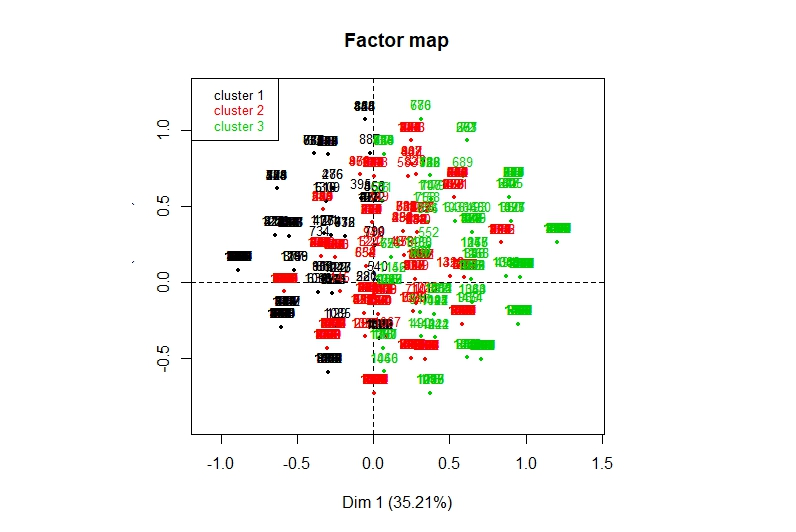

Tagliando il dendrogramma nel punto suggerito dall’algoritmo abbiamo 3 cluster. Per la caratterizzazione di ognuno di essi, andremo a scegliere quelle modalità il cui valore di test è maggiore di 2.

**GRUPPO 1**: le modalità che caratterizzano maggiormente questo gruppo fanno sì che in tale gruppo vi siano le biblioteche che non hanno attivato alcun servizio dopo il lockdown, con lieve preponderanze di quelle private e specialistiche, localizzate perlopiù nel Sud Italia.

**GRUPPO 2**: in questo gruppo abbiamo le biblioteche che hanno puntato sulla digitalizzazione e sull’accesso dei loro contenuti. Tali biblioteche sono in genere private e specialistiche, localizzate nelle due regioni più importanti dal punto di vista politico (Lazio) ed economico (Lombardia), probabilmente per permettere ai lavoratori del settore di poter continuare il loro lavoro durante i mesi di pandemia.

**GRUPPO 3**: abbiamo le biblioteche più attive dal punto di vista social e dell’attenzione verso la comunità dei lettori, visto che sono quelle che hanno maggiormente organizzato attività di laboratorio e di conferenze on line. Tali biblioteche sono perlopiù pubbliche e multidisciplinari, localizzate per la maggior parte nel Veneto (che dall’analisi monovariata abbiamo visto essere la regione con il più alto numero di biblioteche).